# STA32 R Project

Quilvio Hernandez & Hyeonji Choi

6/8/2018

## Problem 1: Create functions which perform the following tasks:

**a) Takes in a vector, and subtracts the mean and divides by the standard deviation (I.e., for every xi finds (xi − x ̄)/s). Then returns the standard deviation of the result. Test the function on the following vector: X = 1:100.**  
The vector 1:100 returns a standard deviation of 1 after each element is evaluated using: $(x_i - \bar{x})/s$. This standard deviation makes sense because the equation $(x_i - \bar{x})/s$ is essentially standarizing the data and returning z-scores, creating normally distributed data with a mean of 0 and a standard deviation of 1.

**b) Takes in a vector and finds the values which are (x ̄ − 2s, x ̄ + 2s), where s is the sample standard deviation, and returns both values, with labels of “lower” and “upper” respectively. Test the function on the following vector: X = 1:100**  
Lower and upper bounds of the vector (1:100) are: (-7.522984, 108.522984). These values are equal to $(\bar{x} - 2s)$ and $(\bar{x} + 2s)$, respectively.

**c) Takes in a vector, and calculates the mean after removing any observations that are more than 3 standard devi- ations from the mean. Test the function on the following vector: Test the function on the following vector: X = c(1:100,200,300)**  
The mean of the vector (1:100, 200, 300) with outliers taken out is: 50.5. This is further evidenced by the mean being equal to the mean of the vector 1:100 (50.5) because 200 and 300 are the only outliers (values are more than 3 standard deviations away).

## Problem 2: The purpose of this problem is to simulate a fair coin flip, and to see how many flips it takes for the probability of a head to be approximately 0.50.

**a) Use the function sample to flip a fair coin 20 times, and find the probability that you flipped a “head” based on the 20 flips.**  
The probability of the coin landing on heads for a 20 flip sample is: 0.5.  
**b) Use an sapply to repeat (a) for the following values of n: 10, 100, 1000, 10000, 100000. Show the probabilities for all 5 values of n.**  
The probability of the coin landing on heads for 10 flips is: 0.3, 100 flips is: 0.45, 1000 flips is 0.504, 10000 flips is: 0.4988, 100000 flips is: 0.50033.  
**c) The error of a coin flip is the absolute value of the estimated probability minus the true probability, i.e error = |0.50 − Pˆ(head)|. Find the error for your simulations from (c)**  
The error is calculated by |$0.50 - \hat{P}(head)$|. The error for 10 flips is: 0.2, 100 flips is: 0.05, 1000 flips is 0.004, 10000 flips is: 0.0012, 100000 flips is: 3.310^{-4}.  
**d) What happens to the error as n increases, and why? Explain your answer.**  
The error decreases as n increases because of the law of large numbers. The law of large numbers states “as the number of experiments increases, the actual ratio of outcomes will converge on the theoretical, or expected, ratio of outcomes”. However, there may be cases where a smaller sample size is closer to our theorical ratio of .5, in general as you increase n, the error will decrease.

## Problem 3: This problem will use R to find all possible orderings of 7 objects, and probabilities associated with them. Consider your vector of possible values to be: values = as.character(1:7)

**a) Use the function sample to draw from values 7 times (without replacement), and return this vector. Notice it is a vector, with 7 values. Display your particular draw.**  
Our random draw is: 6, 4, 1, 3, 2, 5, 7  
**b) Repeat (a) 100000 times using an sapply. Notice the result has 7 rows, and 100000 columns, where each column is a specific random draw. Use this result to find how many of your orderings begin with the character 1.**  
There are 14128 ordering that begin with 1. This is reasonable because, assuming there is an equal probability of the first number being any number from 1 to 7, it should be approximately the ratio 1/7 which is 0.1428571.  
**c) Use your samples from (b) to find the probability that a random ordering started with a 3 and ended with a 7.**  
The probability of a random ordering starting with 3 and ending with 7 is: 0.02326.  
**d) The function paste can collapse a vector of many characters into a single character with the following command: one.order = paste(one.draw,collapse = “”). Modify the above and use it with an sapply to find how many unique orderings of 7 values there are (assuming order matters and no repetitions are allowed).**  
There are 5040 unique possible combinations. This is reinforced by the fact there should be 7! different unique combinations and 7! is 5040.

## Problem 5: On Canvas you will find the file crime.csv. It has two columns, one of which is the percentage of individuals in the county with at least a high-school diploma (column dip), and the other is the crime rate per 100,000 residents for the counties (column rate). Consider Y to be crime rate, and X to be percentage with high school diploma.

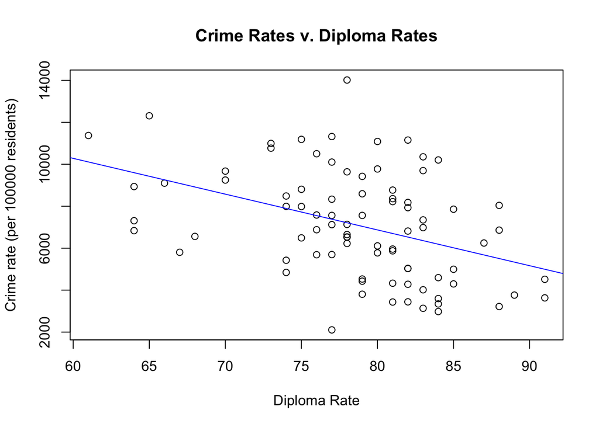

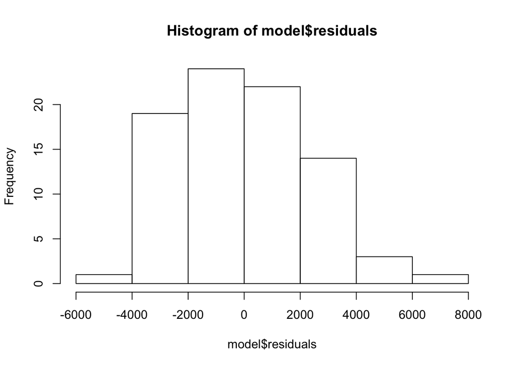

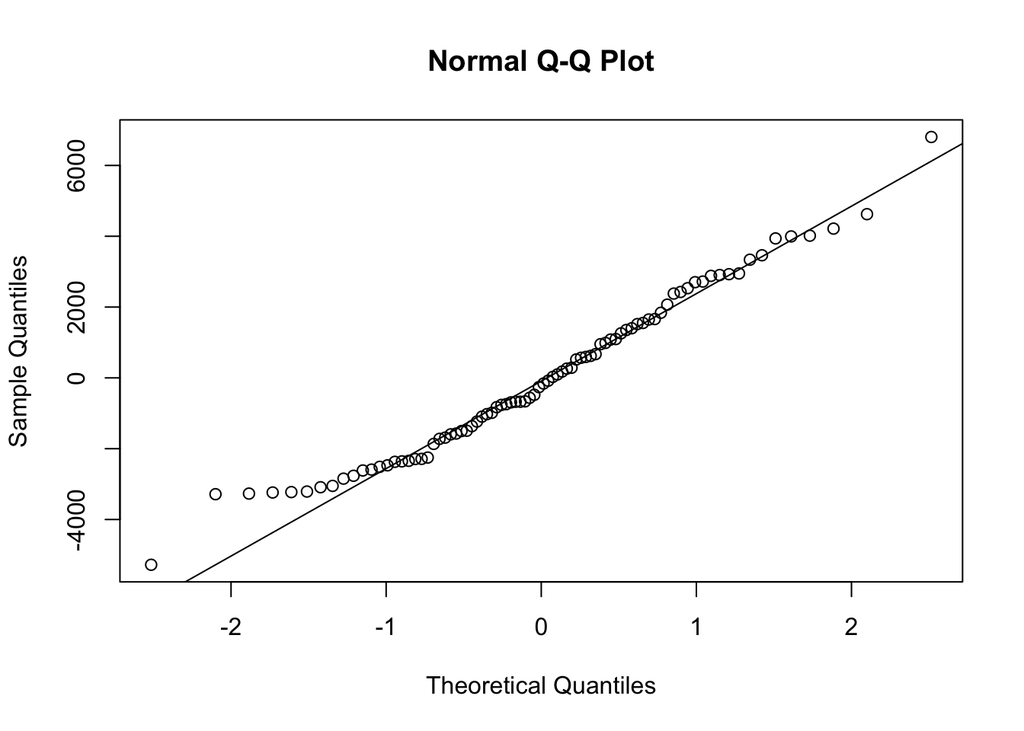

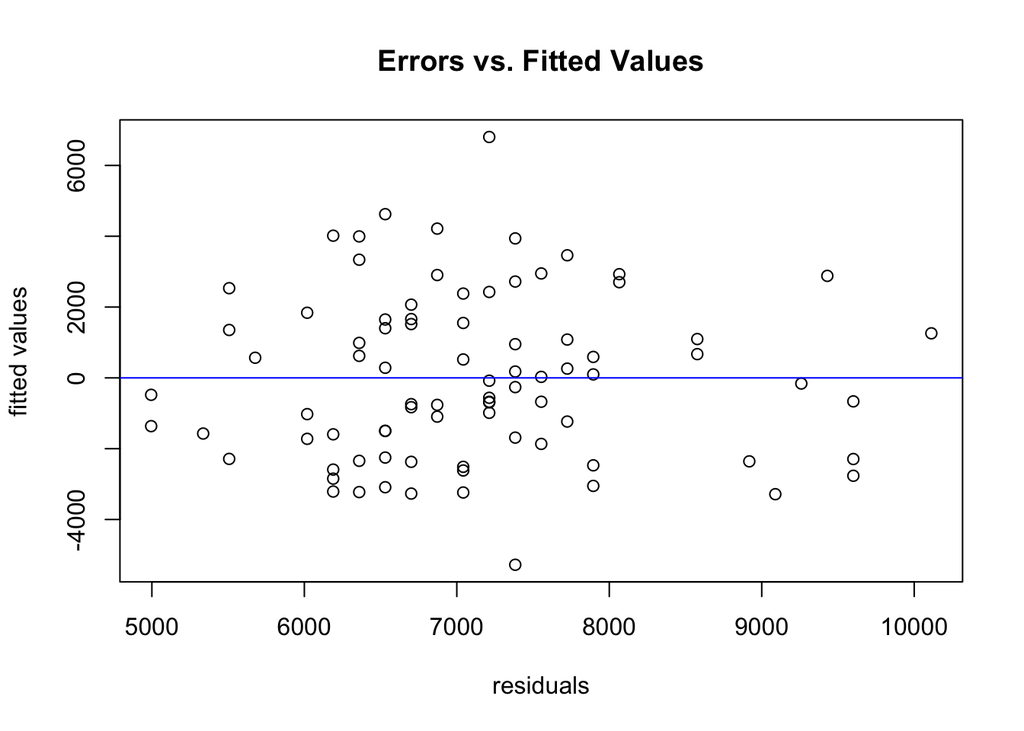

**b) Calculate the estimated regression line.**  
$\hat{crime\_rate} = 20517.6 - 170.6(\hat{diploma\_rate})$  
**c)Interpret the slope and intercept (if appropriate) in terms of the problem.**  
Slope: For each additional increase in the percent of residents with a high school diploma, the number of crimes decreases by 170.6 per 100000 residents. Intercept: If no one had a high school diploma, there would be a crime rate of 20517.6 crimes per 100000 residents. This result is insignificant.  
**d) Does there appear to be outliers in the plot from (a)? If so, identify them in R (for example, list the pair (X,Y) that are outliers, or equivalently the row).**  
There appears to be an outlier at (78, 14016).  
**e)Create a QQ plot (normal probability plot) of the residuals. Does it appear that they are normally distributed? Explain.**  
Yes, they seem to be approximately normal because the QQ plot reveals that points fall about a straight line.  
**f) Create a plot of the errors vs. the fitted values (Yˆi’s). Does it appear the variance of the errors is constant? Explain.**  
Variance of the errors is apploximately constant because points are randomly distributed.  
**g) Find the 95% confidence interval for the slope, and interpret it in terms of the problem. Does the interval suggestthere is a significant linear relationship? Explain.**  
We are 95% condifent that for every percentage increase in high school diploma rates, crimes decrease by between 87 and 253 crimes per 100000 residents.

## Appendix

```r
##1a
X = c(1:100)

Rproject <- function(vector){
  x = mean(vector)
  s = sd(vector)
  for(i in vector){
    (vector[i] <- ((vector[i] - x)/s))
  }
  return(sd(vector))
}
Rproject(X)

##1b
ninetyfivepercent <- function(vector){
  x = mean(vector)
  s = sd(vector)

  two_s = 2 * s
  lower = x - two_s
  upper = x + two_s
  results = c(lower, upper)
  names(results) = c("lower", "upper")
  return(results)
}
ninetyfivepercent(X)

##1c
no_outlier <- function(vector){
  x = mean(vector)
  s = sd(vector)
  three_s = 3*s
  high_outlier = vector[vector > x + three_s]
  low_outlier = vector[vector < x - three_s]
  outliers = c(high_outlier, low_outlier)

  vector = vector [!vector %in% outliers]
  new_mu = mean(vector)
  return(new_mu)
}

mean = mean(X)

X = c(1:100, 200, 300)
no_outlier(X)

##2a
coin.flip = sample(c("H","T"), 20, replace = TRUE)
Prob= mean(coin.flip=="H")
Prob

##2b
many.flips <- function(N){
  coin.flip = sample(2, N, replace = TRUE)
  H = sum(coin.flip == 1)
  P = H / N
  return(P)
}
n = c(10,100,1000,10000,100000)

P_hat = sapply(n, many.flips)

##2c
P_error = abs(.5 - P_hat)

##3a
values = as.character(1:7)
draw = sample (values, 7, replace=FALSE)

##3b
many.draws = sapply(1:100000,function(i){
  draw = sample(values, 7, replace=FALSE)
  return(draw)
})
start_w_1 = sum((many.draws[1, ] == "1") == TRUE)
p_start = 1/7


##3c
start_3_end_7 = sum(many.draws[1, ] == "3" & many.draws[7, ] == "7")
P_start_3_end_7 = start_3_end_7/100000

##3d
answer= sapply(1:ncol(many.draws), function(i){
  paste(many.draws[,i],collapse="")
})
lengthofvalue=length(unique(answer))


##5a
crime <- read.csv("~/Downloads/crime.csv")
{plot(crime$dip, crime$rate, ylab = "Crime rate (per 100000 residents)", xlab = "Diploma Rate", main = "Crime Rates v. Diploma Rates")

#5b and 5c
model = lm(rate ~ dip, data = crime)
abline(model, col = "blue")}

#5d
outlier = c(crime[crime$rate > 14000, ], crime[, crime$rate < 2000])

#5e
hist(model$residuals)
{qqnorm(model$residuals)
qqline(model$residuals)}

##5f
{plot(model$fitted.values, model$residuals, xlab = "residuals", ylab = "fitted values", main = "Errors vs. Fitted Values")
abline(h = 0, col = "blue")}

##5g
confint(model, level = 0.95)
```